# STATS506_HW_02

github link: https://github.com/juanitaW12/stats506

## Load packages

```r
library(readr)
library(dplyr)
library(quarto)
library(ggplot2)
library(interactions)
library(microbenchmark)
```

## Problem 1

### (a)

```r
# version—1, using loop

#' Function for calculating total winnings in the dice game, Version 1
#'
#' @param n
#'
#' @return total_winnings
#' @export
#'
#' @examples
#'
version_1 <- function(n) {
  total_winnings <- 0  #total winned money

  for (i in 1:n) { # n rounds of games
    roll <- sample(1:6, 1)  #the dice in a single round
    if (roll == 3 || roll == 5) {  #if winning
      total_winnings <- total_winnings + 2 * roll - 2 #mimus the cost
    }
    else{  #if losing
      total_winnings <- total_winnings - 2
    }
  }

  return(total_winnings)
}
```

```r
# version-2, using built-in R vectorized functions

#' Function for calculating total winnings in the dice game, Version 2
#'
#' @param n
#'
#' @return total_winnings
#' @export
#'
#' @examples
#'
version_2 <- function(n){

  rolls <- sample(1:6, n, replace = TRUE) #a list of results for each die rolled
  winnings <- ifelse(rolls %in% c(3,5), 2*rolls -2, -2)  #a list of the winning in each round of the game
  total_winnings <- sum(winnings) #sum of winnings

  return(total_winnings)
}
```

```r
# version-3, rolling all the dice into one and collapsing the die rolls into a single table()

#' Function for calculating total winnings in the dice game, Version 3
#'
#' @param n
#'
#' @return total_winnings
#' @export
#'
#' @examples
#'
version_3 <- function(n){

  rolls <- sample(1:6, n, replace = TRUE) #a list of results for each die rolled
  roll_table <- table(rolls) # outputting the frequency of all results

  winnings <- (roll_table["3"] * 2 * 3) + (roll_table["5"] * 2 * 5) # the total winnings if winning games
  winnings[is.na(winnings)] <- 0 #if losing all rounds of games

  total_winnings <- as.numeric(winnings) - 2 * n #minus the costs

  return(total_winnings)
}
```

```r
# version-4, using apply

#' Function for calculating total winnings in the dice game, Version 4
#'
#' @param n
#'
#' @return total_winnings
#' @export
#'
#' @examples
#'
version_4 <- function(n){

  rolls <- sample(1:6, n, replace = TRUE) #a list of results for each die rolled

  winnings <- sapply(rolls, function(x) ifelse(x %in% c(3, 5), 2 * x - 2, -2)) # winnings in each round
  total_winnings <- sum(winnings)

  return(total_winnings)
}
```

### (b) & (c)

```r
print('The results of version-1:')
```

```
[1] "The results of version-1:"
```

```r
print(version_1(3))
```

```
[1] -6
```

```r
print(version_1(3000))
```

```
[1] 1682
```

```r
print('The results of version-2:')
```

```
[1] "The results of version-2:"
```

```r
print(version_2(3))
```

```
[1] 10
```

```r
print(version_2(3000))
```

```
[1] 2328
```

```r
print('The results of version-3:')
```

```
[1] "The results of version-3:"
```

```r
print(version_3(3))
```

```
[1] 10
```

```r
print(version_3(3000))
```

```
[1] 1972
```

```r
print('The results of version-4:')
```

```
[1] "The results of version-4:"
```

```r
print(version_4(3))
```

```
[1] 6
```

```r
print(version_4(3000))
```

```
[1] 1964
```

### (c)

To ensure reproducibility, I will set a same random seed for four versions of functions.

```r
set.seed(1) #for reproducibility
print('The results of version-1:')
```

```
[1] "The results of version-1:"
```

```r
print(version_1(3))
```

```
[1] -6
```

```r
print(version_1(3000))
```

```
[1] 2174
```

```r
set.seed(1)
print('The results of version-2:')
```

```
[1] "The results of version-2:"
```

```r
print(version_2(3))
```

```
[1] -6
```

```r
print(version_2(3000))
```

```
[1] 2174
```

```r
set.seed(1)
print('The results of version-3:')
```

```
[1] "The results of version-3:"
```

```r
print(version_3(3))
```

```
[1] -6
```

```r
print(version_3(3000))
```

```
[1] 2174
```

```r
set.seed(1)
print('The results of version-4:')
```

```
[1] "The results of version-4:"
```

```r
print(version_4(3))
```

```
[1] -6
```

```r
print(version_4(3000))
```

```
[1] 2174
```

We can see all the results of four versions are same.

### (d)

```r
performance <- microbenchmark(
  version_1(1000),
  version_2(1000),
  version_3(1000),
  version_4(1000),
  version_1(100000),
  version_2(100000),
  version_3(100000),
  version_4(100000)
)
performance
```

```
Unit: microseconds
             expr        min          lq        mean      median          uq
  version_1(1000)   3555.182   4065.9230   4915.0019   4463.7395   4728.5605
  version_2(1000)     85.228    105.4640    119.9540    113.1460    125.4185
  version_3(1000)    206.476    250.7515    296.0236    291.5315    321.1180
  version_4(1000)   2575.400   3032.9400   3671.2556   3366.1510   3628.6745
 version_1(1e+05) 433670.632 486287.0450 511626.7607 517218.5595 532632.8400
 version_2(1e+05)   7256.416   8756.2620  10198.6774   9914.1485  10765.3595
 version_3(1e+05)   8660.162  10654.7360  11329.9185  11311.5390  11862.8730
 version_4(1e+05) 308389.238 353102.3855 382249.8731 381939.4065 405104.2270
        max neval
  16373.829   100
    229.133   100
    721.671   100
  13846.788   100
 630364.998   100
  20921.620   100
  17697.328   100
 518795.246   100
```

### (e)

Firstly, I will make a definition for a fair game here. if the average winnings across all simulations equals to the cost to play, it is a fair game to both the player and dealer. So we need to compare the average winnings to the cost per round. That is, if the ratio of average winnings to average costs in the game is close to 1, the game is fair.

```r
# creating a function for Monte Carlo simulation
monte_carlo_simulation <- function(n, rolls) {
  total_winnings <- numeric(n) #iterations

  for (i in 1:n) {
    total_winnings[i] <- version_2(rolls) # using the fastest version of function
  }
  comparision_result <- mean(total_winnings / rolls)

  return(comparision_result)
}
```

```r
result1 <- monte_carlo_simulation(1000000, 1)
print(result1)
```

```
[1] 0.665772
```

```r
result2 <- monte_carlo_simulation(1000000, 10)
print(result2)
```

```
[1] 0.6658414
```

It shows that the game is not fair.

## Problem 2

### (a)

Firstly, I will import the cars data. Then I will rename the columns’ names after investigating the original variables’ names.

```r
# import the cars data
data_path <- file.path( "cars.csv")
cars <- read.csv(data_path, sep = ",", header = TRUE)
# outputting columns' names
colnames(cars)
```

```
 [1] "Dimensions.Height"
 [2] "Dimensions.Length"
 [3] "Dimensions.Width"
 [4] "Engine.Information.Driveline"
 [5] "Engine.Information.Engine.Type"
 [6] "Engine.Information.Hybrid"
 [7] "Engine.Information.Number.of.Forward.Gears"
 [8] "Engine.Information.Transmission"
 [9] "Fuel.Information.City.mpg"
[10] "Fuel.Information.Fuel.Type"
[11] "Fuel.Information.Highway.mpg"
[12] "Identification.Classification"
[13] "Identification.ID"
[14] "Identification.Make"
[15] "Identification.Model.Year"
[16] "Identification.Year"
[17] "Engine.Information.Engine.Statistics.Horsepower"
[18] "Engine.Information.Engine.Statistics.Torque"
```

```r
# Rename the columns of the data to more reasonable lengths.
column_names <- c("D_Height",
                  "D_Length",
                  "D_Width",
                  "Engine_Driveline",
                  "Engine_Type",
                  "Engine_Hybrid",
                  "Engine_Number_Gears",
                  "Engine_Transmission",
                  "Fuel_City_mpg",
                  "Fuel_Type",
                  "Fuel_Highway_mpg",
                  "ID_Classification",
                  "ID",
                  "ID_Make",
                  "ID_Model_Year",
                  "ID_Year",
                  "Engine_Horsepower",
                  "Engine_Torque")
colnames(cars) <- column_names
colnames(cars)
```

```
 [1] "D_Height"            "D_Length"            "D_Width"
 [4] "Engine_Driveline"    "Engine_Type"         "Engine_Hybrid"
 [7] "Engine_Number_Gears" "Engine_Transmission" "Fuel_City_mpg"
[10] "Fuel_Type"           "Fuel_Highway_mpg"    "ID_Classification"
[13] "ID"                  "ID_Make"             "ID_Model_Year"
[16] "ID_Year"             "Engine_Horsepower"   "Engine_Torque"
```

### (b)

```r
# Restrict the data to cars whose Fuel Type is “Gasoline”.
cars_gasoline <- subset(cars, Fuel_Type == "Gasoline")
head(cars_gasoline)
```

```
  D_Height D_Length D_Width  Engine_Driveline
1      140      143     202   All-wheel drive
2      140      143     202 Front-wheel drive
3      140      143     202 Front-wheel drive
4      140      143     202   All-wheel drive
5      140      143     202   All-wheel drive
6       91       17      62   All-wheel drive
                                   Engine_Type Engine_Hybrid
1         Audi 3.2L 6 cylinder 250hp 236ft-lbs          True
2 Audi 2.0L 4 cylinder 200 hp 207 ft-lbs Turbo          True
3 Audi 2.0L 4 cylinder 200 hp 207 ft-lbs Turbo          True
4 Audi 2.0L 4 cylinder 200 hp 207 ft-lbs Turbo          True
5 Audi 2.0L 4 cylinder 200 hp 207 ft-lbs Turbo          True
6        Audi 3.2L 6 cylinder 265hp 243 ft-lbs          True
  Engine_Number_Gears            Engine_Transmission Fuel_City_mpg Fuel_Type
```

[output cut: 20 more lines]

### (c)

Firstly, I output the summary and the distribution plot of MPG in highway.

```r
summary(cars_gasoline$Fuel_Highway_mpg)
```

```
   Min. 1st Qu.  Median    Mean 3rd Qu.    Max.
  13.00   21.00   25.00   24.97   28.00  223.00
```

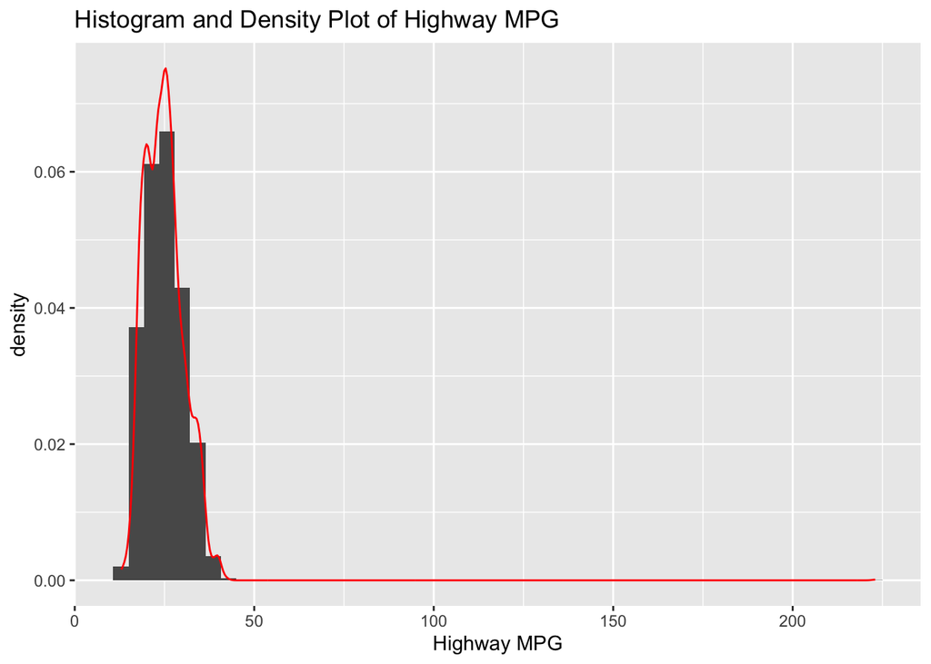

```r
# outputting the visualization of the distribution of MPG in highway
ggplot(cars_gasoline, aes(x = Fuel_Highway_mpg)) +
  geom_histogram(aes(y = ..density..), bins = 50) +
  geom_density(color = "red") +
  labs(title = "Histogram and Density Plot of Highway MPG", x = "Highway MPG", y = "density")
```

Then, I use Shapiro-Wilk test to check for the normality.

```r
# shapiro-wilk test
shapiro_test <- shapiro.test(cars_gasoline$Fuel_Highway_mpg)
shapiro_test
```

```
    Shapiro-Wilk normality test

data:  cars_gasoline$Fuel_Highway_mpg
W = 0.79257, p-value < 2.2e-16
```

Obviously, p-value is less than 0.05, so the distribution of data is not normal. And the skewness of the data is right-skewed, so I decide to use a log transformation.

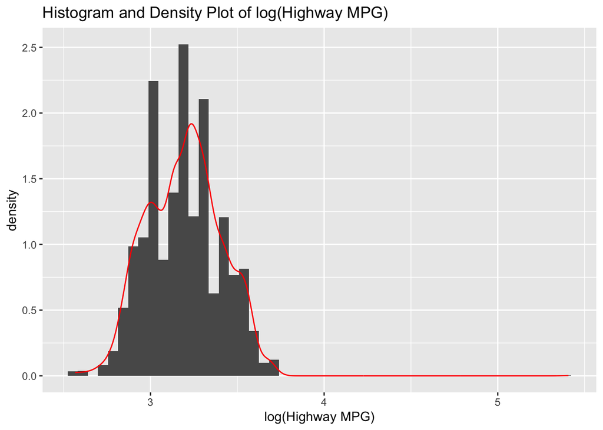

```r
# apply the transformation
cars_gasoline$logMPG <- log(cars_gasoline$Fuel_Highway_mpg)

# visualizing the transformated MPG data
ggplot(cars_gasoline, aes(x = logMPG)) +
  geom_histogram(aes(y = ..density..), bins = 50) +
  geom_density(color = "red") +
  labs(title = "Histogram and Density Plot of log(Highway MPG)", x = "log(Highway MPG)", y = "density")
```

### (d)

I will fit a linear regression model predicting MPG on the highway, using torque as a continuous variable while controlling for horsepower, dimensions, and year which is a categorical variable.

```r
# horsepower: Engine_Horsepower; dimensions: D_Height, D_Length, D_Width; year: ID_Year

# convert cars_gasoline$ID_Year to a categorical variable
cars_gasoline$ID_Year <- as.factor(cars_gasoline$ID_Year)

# linear regression
model_d <- lm(Fuel_Highway_mpg ~ Engine_Torque + Engine_Horsepower + D_Height + D_Length + D_Width + ID_Year,
              data = cars_gasoline)
```

```r
summary(model_d)
```

```
Call:
lm(formula = Fuel_Highway_mpg ~ Engine_Torque + Engine_Horsepower +
    D_Height + D_Length + D_Width + ID_Year, data = cars_gasoline)

Residuals:
    Min      1Q  Median      3Q     Max
-10.824  -2.550  -0.452   2.372 202.639

Coefficients:
                    Estimate Std. Error t value Pr(>|t|)
(Intercept)       32.2926630  0.7225982  44.690  < 2e-16 ***
Engine_Torque     -0.0507425  0.0022030 -23.034  < 2e-16 ***
Engine_Horsepower  0.0163556  0.0022772   7.182 7.96e-13 ***
D_Height           0.0099079  0.0011267   8.794  < 2e-16 ***
D_Length           0.0017290  0.0008836   1.957   0.0504 .
D_Width           -0.0003343  0.0009045  -0.370   0.7117
ID_Year2010       -0.4539681  0.6768246  -0.671   0.5024
ID_Year2011        0.1711016  0.6757043   0.253   0.8001
ID_Year2012        1.3029279  0.6810076   1.913   0.0558 .
---
Signif. codes:  0 '***' 0.001 '**' 0.01 '*' 0.05 '.' 0.1 ' ' 1

Residual standard error: 4.602 on 4582 degrees of freedom
Multiple R-squared:  0.4192,    Adjusted R-squared:  0.4182
F-statistic: 413.3 on 8 and 4582 DF,  p-value: < 2.2e-16
```

As is showed above, the relationship between torque and highway MPG is negative. The torque coefficient is -0.0507425, which means a unit change in torque will result in -0.051 unit change in highway MPG when controlling horsepower, dimensions and year.

Besides, p-value of torque coefficient is less than 2e-16, which is definitely less than 0.05. So the torque coefficient is significant.

### (e)

As there may be an interaction between torque and horsepower, I will construct the interaction model.

```r
# the interaction model
model_e <- lm(Fuel_Highway_mpg ~ Engine_Torque*Engine_Horsepower + D_Height + D_Length + D_Width + ID_Year,
              data = cars_gasoline)

summary(model_e)
```

```
Call:
lm(formula = Fuel_Highway_mpg ~ Engine_Torque * Engine_Horsepower +
    D_Height + D_Length + D_Width + ID_Year, data = cars_gasoline)

Residuals:
    Min      1Q  Median      3Q     Max
-11.109  -2.313  -0.258   2.062 203.540

Coefficients:
                                  Estimate Std. Error t value Pr(>|t|)
(Intercept)                      4.219e+01  7.930e-01  53.199  < 2e-16 ***
Engine_Torque                   -8.606e-02  2.533e-03 -33.972  < 2e-16 ***
Engine_Horsepower               -1.666e-02  2.539e-03  -6.563 5.84e-11 ***
D_Height                         6.560e-03  1.070e-03   6.133 9.32e-10 ***
D_Length                         1.777e-03  8.318e-04   2.136   0.0327 *
D_Width                         -1.169e-03  8.521e-04  -1.372   0.1700
ID_Year2010                     -5.628e-01  6.372e-01  -0.883   0.3771
ID_Year2011                      7.254e-02  6.361e-01   0.114   0.9092
ID_Year2012                      1.197e+00  6.411e-01   1.867   0.0619 .
Engine_Torque:Engine_Horsepower  1.124e-04  4.628e-06  24.276  < 2e-16 ***
---
Signif. codes:  0 '***' 0.001 '**' 0.01 '*' 0.05 '.' 0.1 ' ' 1

Residual standard error: 4.333 on 4581 degrees of freedom
Multiple R-squared:  0.4854,    Adjusted R-squared:  0.4844
F-statistic: 480.1 on 9 and 4581 DF,  p-value: < 2.2e-16
```

Next, I will print the summary of Engine_Torque and Engine_Horsepower to choose reasonable values.

```r
print('summary of Engine_Torque:')
```

```
[1] "summary of Engine_Torque:"
```

```r
summary(cars_gasoline$Engine_Torque)
```

```
   Min. 1st Qu.  Median    Mean 3rd Qu.    Max.
   98.0   177.0   257.0   267.2   332.0   774.0
```

```r
print('summary of Engine_Horsepower:')
```

```
[1] "summary of Engine_Horsepower:"
```

```r
summary(cars_gasoline$Engine_Horsepower)
```

```
   Min. 1st Qu.  Median    Mean 3rd Qu.    Max.
  100.0   185.0   263.0   267.5   317.0   638.0
```

For torque, I choose the minimun, median, and maximum of torque as pred.values.

For horsepower, I choose the mean, mean+1*SD, mean-1*SD of horsepower values as modx.values, which are the default values.

```r
median_torque <- median(cars_gasoline$Engine_Torque)
max_torque <- max(cars_gasoline$Engine_Torque)
min_torque <- min(cars_gasoline$Engine_Torque)
torque_values = c(min_torque, median_torque, max_torque)
```

Finally, I will generate an interaction plot.

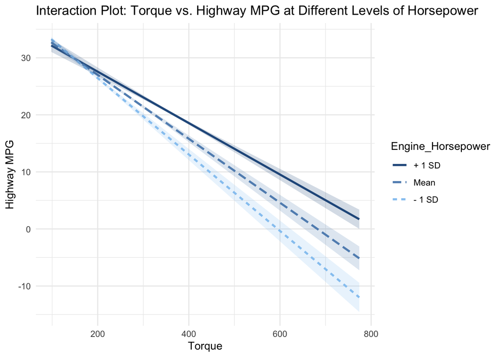

```r
# Create a grid of values for the plot, controlling for year as 2010
interaction_plot <- interact_plot(model_e,
                                  pred = Engine_Torque,
                                  modx = Engine_Horsepower,
                                  at = list(ID_Year = '2010'),
                                  pred.values = torque_values,
                                  interval = TRUE)

# Add labels and title
interaction_plot +
  labs(title = "Interaction Plot: Torque vs. Highway MPG at Different Levels of Horsepower",
       x = "Torque",
       y = "Highway MPG") +
  theme_minimal()
```

### (f)

In this part, I will firstly create the design matrix, and then use the equation - beta = (X’X)^-1 X’y - to calculate beta. Then I will compare the result to the that in linear regression of (d).

```r
# creating the design matrix
X <- model.matrix(~ Engine_Torque + Engine_Horsepower + D_Height + D_Length + D_Width + ID_Year,
                  data = cars_gasoline)
y <- cars_gasoline$Fuel_Highway_mpg
```

```r
# calculating coefficients manually
# (X'X)^-1
XtX_inv <- solve(t(X) %*% X)

# X'y
XtY <- t(X) %*% y

# beta = (X'X)^-1 X'y
beta_f <- XtX_inv %*% XtY

beta_f
```

```
                           [,1]
(Intercept)       32.2926630057
Engine_Torque     -0.0507424622
Engine_Horsepower  0.0163556341
D_Height           0.0099078942
D_Length           0.0017289759
D_Width           -0.0003343217
ID_Year2010       -0.4539681241
ID_Year2011        0.1711016371
ID_Year2012        1.3029279007
```

```r
summary(model_d)$coefficients
```

```
                       Estimate   Std. Error     t value      Pr(>|t|)
(Intercept)       32.2926630057 0.7225982233  44.6896518  0.000000e+00
Engine_Torque     -0.0507424622 0.0022029804 -23.0335509 3.565652e-111
Engine_Horsepower  0.0163556341 0.0022771803   7.1824064  7.955345e-13
D_Height           0.0099078942 0.0011267222   8.7935551  2.017410e-18
D_Length           0.0017289759 0.0008836265   1.9566817  5.044555e-02
D_Width           -0.0003343217 0.0009044502  -0.3696408  7.116673e-01
ID_Year2010       -0.4539681241 0.6768245819  -0.6707323  5.024249e-01
ID_Year2011        0.1711016371 0.6757042823   0.2532197  8.001098e-01
ID_Year2012        1.3029279007 0.6810075845   1.9132355  5.578017e-02
```

As is showed above, they have same results.